# Correlaciones ordinales y matrices de correlación

Sesión del miércoles, 7 de octubre de 2026

[Ejercita R · Social R interactivo ↗](https://karavena.github.io/social-r/)

[Recurso complementario Interactivo · Spearman y Kendall ↗](https://karavena.github.io/estadistica-social/modules/m10_correlaciones_ordinales_spearman_kendall.html)

[Recurso complementario Interactivo · Matrices y casos perdidos ↗](https://karavena.github.io/estadistica-social/modules/m11_matrices_correlacion_casos_perdidos.html)

## 1 Objetivo de la sesión

Los objetivos de esta sesión son revisar los siguientes contenidos:

- Repasar cuándo utilizar los coeficientes de Pearson, Spearman y Kendall
- Estimar e interpretar matrices de correlación, decidiendo cómo tratar los casos perdidos
- Integrar visualización, inferencia, magnitud y sentido de la asociación en un reporte breve

La actividad autónoma en esta sesión será distinta a versiones anteriores: en esta ocasión, daremos a elegir bases de datos con las que trabajar y el foco estará en **tomar decisiones de análisis, ejecutarlas en R y justificarlas**

## 2 Correlaciones Ordinales y Matrices de Correlación

### 2.1 Preparación de datos

```r
# Cargamos los paquetes que utilizaremos en el práctico

if (!requireNamespace("pacman", quietly = TRUE)) install.packages("pacman")

pacman::p_load(
  dplyr,     # Para trabajar con los datos
  ggplot2,   # Para crear gráficos
  sjmisc,    # Para explorar frecuencias
  sjPlot,    # Para tablas de correlación
  corrplot,  # Para visualizar matrices de correlación
  psych      # Para contar casos por pares
)
```

[output not shown]

Utilizaremos datos del **Estudio Longitudinal Social de Chile (ELSOC)**, una encuesta panel aplicada anualmente por el Centro de Estudios de Conflicto y Cohesión Social (COES) a población urbana adulta de Chile. Trabajaremos con la ola más reciente disponible (**2023**), y en particular con preguntas sobre percepción de meritocracia y estatus social subjetivo. Con el siguiente código cargamos y procesamos los datos.

```r
load(url("https://github.com/cursos-metodos-facso/datos-ejemplos/raw/main/elsoc2023.rdata"))  # Carga el objeto elsoc 2023

datos <- elsoc_2023 |>
  transmute(
    mesfuerzo = c18_09,                           # Recompensa al esfuerzo
    mtalento = c18_10,                            # Recompensa a la inteligencia
    ess = d01_01,                                 # Estatus social subjetivo
    educ = m01,                                   # Nivel educacional
    edad = m0_edad                                # Edad
  ) |>
  select(mesfuerzo,
        mtalento,
        ess,
        educ,
        edad) |>
   sjmisc::set_na(na = c(-999, -888, -777, -666))  # Codificamos los casos negativos como casos perdidos
```

| Variable | Qué representa | Nivel de medición |
| --- | --- | --- |
| `mesfuerzo` | “En Chile las personas son recompensadas por sus esfuerzos” (1 = totalmente en desacuerdo … 5 = totalmente de acuerdo) | Ordinal |
| `mtalento` | “En Chile las personas son recompensadas por su inteligencia” (1 … 5) | Ordinal |
| `ess` | Estatus social subjetivo (0 = el nivel más bajo … 10 = el nivel más alto) | Ordinal |
| `educ` | Nivel educacional (1 = sin estudios … 10 = posgrado) | Ordinal |
| `edad` | Edad en años | Razón |

**Importante**

En ocasiones, variables ordinales con muchas categorías, como Estatus Social Subjetivo y Nivel Educacional, pueden ser tratadas como continuas.

Por ahora, para demostrar la aplicación de los coeficientes de Spearman y Kendall en R, asumiremos que son ordinales.

### 2.2 Spearman y Kendall en R

Trabajaremos con la siguiente pregunta de investigación: **¿En qué medida el nivel educacional se asocia con el estatus social subjetivo?**

Primero visualizamos. A diferencia de lo que vimos con variables continuas (como ingresos o edad), donde la nube de puntos se distribuye libremente en el plano, al cruzar **dos variables ordinales** cada variable toma solo unos pocos valores posibles. Por eso, el gráfico de dispersión ya no muestra una “nube”, sino una **cuadrícula** de puntos: cada punto corresponde a una combinación de categorías (por ejemplo, educación media completa y estatus 5) y puede representar a decenas o cientos de personas superpuestas.

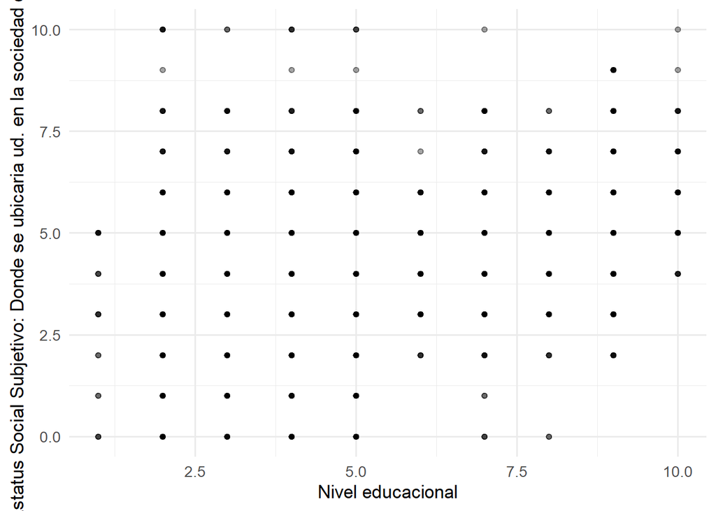

Nivel educacional y estatus social subjetivo · ELSOC 2023

```r
ggplot(datos, aes(
  x = educ,                              # Eje X: nivel educacional
  y = ess                                # Eje Y: estatus social subjetivo
)) + geom_point()
```

En este gráfico no podemos distinguir en qué combinaciones se concentran los casos, por lo que es difícil identificar el patrón de la asociación. Una alternativa es usar `geom_jitter()`, que desplaza levemente cada punto al azar para que los casos superpuestos se vuelvan visibles. Así, las zonas con más puntos indican dónde se concentran las personas:

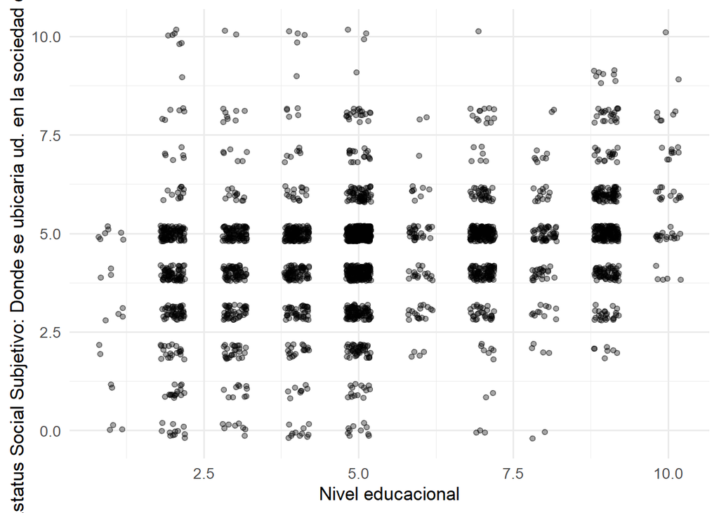

Nivel educacional y estatus social subjetivo (con jitter) · ELSOC 2023

```r
ggplot(datos, aes(
  x = educ,
  y = ess
)) + geom_jitter(width = 0.2, height = 0.2)  # Desplaza los puntos hasta 0,2 unidades en cada eje
```

**Importante**

El desplazamiento de `geom_jitter()` es solo visual: **no modifica los datos** ni el cálculo de la correlación.

> ¿Se puede identificar algún patrón a partir de esta visualización?

### 2.3 ¿Qué coeficiente utilizar?

Hasta ahora, hemos trabajado con el coeficiente de correlación de Pearson, que supone variables continuas y que tienen una relación lineal entre ellas. Sin embargo, en ciencias sociales muchas veces trabajamos con variables que son ordinales: Escalas Likert, nivel educacional, clase social, etc. Para estos casos, existen coeficientes de relación basados en **rankings**: El Coeficiente de correlación de Spearman y el Coeficiente de correlación de rango de Kendall.

| Coeficiente | Símbolo | ¿Cuándo usarlo? | ¿Cómo se calcula? |
| --- | --- | --- | --- |
| Pearson | $r$ | Variables continuas y relación lineal. Es el coeficiente más utilizado | Covarianza estandarizada de los valores originales |
| Spearman | $r_s$ | Variables ordinales, o continuas con distribuciones muy asimétricas o casos atípicos (ej. ingresos) | Es una correlación de Pearson calculada sobre el **ranking** (posiciones ordenadas) de las variables |
| Kendall | $\tau$ | Variables ordinales con **muchos empates** (pocas categorías) y/o muestras pequeñas | Compara todos los pares de casos: proporción de pares **concordantes** menos **discordantes** |

Los tres coeficientes se interpretan de la misma forma:

- Varían entre -1 y 1.
- Su **signo** indica el sentido de la asociación.
- Su **valor absoluto** indica su magnitud, que se puede interpretar según los criterios de Cohen. Con todo, se debe considerar que los valores de Kendall tienden a ser más pequeños que los de Spearman y Pearson.

Para estimar Spearman o Kendall usamos la misma función `cor.test` que utilizamos para Pearson, cambiando el argumento `method`:

```r
cor_pearson <- cor.test(datos$educ, datos$ess, method = "pearson")
cor_spearman <- cor.test(datos$educ, datos$ess, method = "spearman", exact = FALSE)
cor_kendall <- cor.test(datos$educ, datos$ess, method = "kendall", exact = FALSE)
```

**Tip**

El argumento `exact = FALSE` le indica a R que calcule el valor $p$ mediante una aproximación. Si no lo incluimos, cuando hay **empates** (casos con el mismo valor, muy frecuentes en variables ordinales) R puede mostrar el aviso *“Cannot compute exact p-value with ties”*. No es un error: el coeficiente se calcula igual.

Comparemos los tres coeficientes:

| Coeficiente | Valor | Valor $p$ |
| --- | --- | --- |
| Pearson ($r$) | 0,26 | < 0,001 |
| Spearman ($r_s$) | 0,26 | < 0,001 |
| Kendall ($\tau$) | 0,21 | < 0,001 |

Dado que en este caso tenemos una muestra grande y variables ordinales, nos guiaremos por el Coeficiente de Correlación de Spearman. A continuación, interpretamos el resultado:

**AdvertenciaInterpretación**

Dado que ambas variables son ordinales, se utilizó la correlación de Spearman para medir la asociación entre nivel educacional y estatus social subjetivo. Se observa una asociación positiva, de magnitud pequeña y estadísticamente significativa entre ambas variables ($r_s$ = 0,26; $p$ < 0,001; $N$ = 2.719). Por tanto, dado que $p$ < 0,001, existe evidencia estadística suficiente para rechazar la hipótesis nula de ausencia de asociación. Por lo tanto, detectamos evidencia de que las personas con mayor nivel educacional tienden a ubicarse en posiciones más altas en la escala de estatus social.

**Importante**

`cor.test` solo entrega **intervalo de confianza** para la correlación de Pearson. Para Spearman y Kendall solo reportamos el coeficiente, el valor $p$ y el $N$.

### 2.4 Matrices de correlación

Hasta ahora hemos analizado la asociación entre dos variables. Si quisiéramos examinar simultáneamente las asociaciones entre varias variables a la vez, podemos organizarlas en una matriz de correlación. Una **matriz de correlación** presenta simultáneamente todas las correlaciones entre pares de un conjunto de variables. Cada celda corresponde a la correlación entre la variable de la fila y la de la columna; la diagonal siempre es 1 (la correlación de una variable consigo misma) y los valores sobre y bajo la diagonal se repiten.

#### Tratamiento de casos perdidos

Tratar con casos perdidos es complejo, existiendo múltiples enfoques desde la eliminación a la imputación. En este práctico nos enfocaremos en las dos estrategias más comunes:

- Trabajar exclusivamente con casos completos, o *listwise*
- Retener valores perdidos, pero excluirlos al calcular cada estadístico, o *pairwise*

| Opción | Qué hace | En `cor` |
| --- | --- | --- |
| **Listwise** (por lista) | Elimina el caso completo si tiene un `NA` en **cualquiera** de las variables de la matriz. Todas las correlaciones usan el mismo $N$ | `use = "complete.obs"` |
| **Pairwise** (por pares) | Elimina el caso solo de las correlaciones donde tiene `NA`. Cada correlación puede tener un $N$ distinto, pero se rescata más información | `use = "pairwise.complete.obs"` |

La siguiente figura ilustra los efectos de cada tratamiento:

[figure not shown]

Figura 1: Eliminación listwise y pairwise de casos perdidos

A partir de las variables que seleccionamos de ELSOC, veamos cuántos casos tenemos con cada opción:

```r
colSums(is.na(datos))       # Casos perdidos por variable
```

```
mesfuerzo  mtalento       ess      educ      edad
        6         5         7         0         0
```

```r
nrow(datos)                 # N total
```

```
[1] 2726
```

```r
nrow(na.omit(datos))        # N con listwise
```

```
[1] 2713
```

```r
psych::pairwiseCount(datos) # N de cada par con pairwise
```

```
          mesfuerzo mtalento  ess educ edad
mesfuerzo      2720     2718 2714 2720 2720
mtalento       2718     2721 2716 2721 2721
ess            2714     2716 2719 2719 2719
educ           2720     2721 2719 2726 2726
edad           2720     2721 2719 2726 2726
```

En este caso la pérdida de casos es pequeña (de 2.726 a 2.713 con *listwise*). Pero cuando una variable concentra muchos casos perdidos (por ejemplo, ingresos), la diferencia puede ser considerable y la decisión sí importa.

**Importante¿Qué decisión tomar?**

Ninguna opción es más correcta que la otra. La decisión debe depender de cuántos casos se pierden y para qué se usará la matriz. *Pairwise* aprovecha toda la información disponible, por lo que el análisis resultante tendrá más poder estadístico. Sin embargo, *listwise* es más simple de computar y es necesario para técnicas de estadística multivariada.

En este caso, como la diferencia entre ambas opciones es pequeña y no arriesgamos poder estadístico, optaremos por *listwise*

#### Estimación de la matriz

Con `cor` obtenemos la matriz completa, indicando el método y el tratamiento de los casos perdidos:

```r
# Creamos un objeto llamado "matriz"
matriz <- cor(datos,
              method = "spearman", # Lo calcularemos con la correlación de Spearman
              use = "complete.obs")  # Solo casos completos, es decir, Listwise
```

Para reportarla, `sjPlot::tab_corr` genera una tabla que además indica la **significación estadística** de cada correlación mediante asteriscos:

```r
sjPlot::tab_corr(datos,
                 corr.method = "spearman",  # "pearson", "spearman" o "kendall"
                 na.deletion = "listwise",  # "listwise" o "pairwise"
                 triangle = "lower",        # Mostramos solo la mitad inferior
                 title = "Matriz de correlaciones de Spearman · ELSOC 2023")
```

Matriz de correlaciones de Spearman · ELSOC 2023

|  | Grado de acuerdo: Las personas son recompensadas por sus esfuerzos | Grado de acuerdo: Las personas son recompensada por su inteligencia | Estatus Social Subjetivo: Donde se ubicaria ud. en la sociedad chilena | Nivel educacional | Edad del entrevistado |
| --- | --- | --- | --- | --- | --- |
| Grado de acuerdo: Las personas son recompensadas por sus esfuerzos |  |  |  |  |  |
| Grado de acuerdo: Las personas son recompensada por su inteligencia | 0.697*** |  |  |  |  |
| Estatus Social Subjetivo: Donde se ubicaria ud. en la sociedad chilena | 0.051** | 0.066*** |  |  |  |
| Nivel educacional | -0.068*** | -0.085*** | 0.261*** |  |  |
| Edad del entrevistado | 0.083*** | 0.089*** | -0.052** | -0.426*** |  |
| Computed correlation used spearman-method with listwise-deletion. |  |  |  |  |  |

Y `corrplot` nos permite visualizarla:

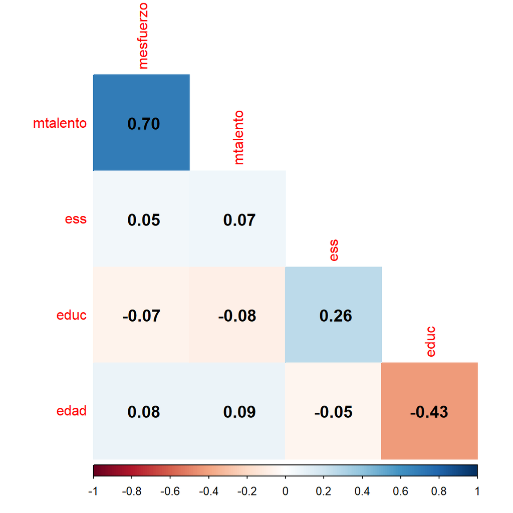

```r
corrplot::corrplot(matriz,
                   method = "color",         # Colorea cada celda según el coeficiente
                   addCoef.col = "black",    # Escribe el coeficiente en negro
                   number.cex = 1.2,         # Tamaño de los números
                   type = "lower",           # Solo la mitad inferior
                   diag = FALSE)             # Sin la diagonal
```

**AdvertenciaLectura de la matriz**

- La asociación más fuerte se da entre `mesfuerzo` y `mtalento` ($r_s$ = 0,70, grande): quienes creen que en Chile se recompensa el esfuerzo también tienden a creer que se recompensa el talento.
- `educ` y `edad` presentan una asociación negativa y moderada ($r_s$ = -0,43): las personas de mayor edad tienen, en promedio, menor nivel educacional.
- Como ya vimos antes, también existe una asociación leve y positiva entre nivel educacional y estatus social subjetivo.
- Con un $N$ cercano a 2.700, incluso correlaciones muy pequeñas pueden resultar estadísticamente significativas.

### 2.5 Checklist para reportar una correlación

Al interpretar una correlación, consideren siempre:

1. **Visualización**: ¿qué patrón muestra el gráfico?
2. **Elección del coeficiente**: ¿por qué Pearson, Spearman o Kendall? (nivel de medición, distribución, tamaño de la muestra)
3. **Sentido**: positivo o negativo, y qué significa sustantivamente
4. **Magnitud**: ¿Qué tan cerca de 0 o |1| está el coeficiente?
5. **Inferencia**: hipótesis, valor $p$, decisión respecto a $H_0$ y nivel de confianza
6. **Casos perdidos**: $N$ utilizado y tratamiento de los `NA`
7. **Conclusión sustantiva**: responder la pregunta de investigación en lenguaje sociológico, sin afirmar causalidad

## 3 Actividad autónoma

En grupos de 2 a 3 personas, elijan **una** de las tres bases de datos disponibles. Luego, desarrollen los ejercicios en un script propio.

**Nota**

Si tienen dudas sobre el código, pueden revisar los ejemplos de este práctico o consultar la sección de ayuda de código. En esa sección también podrán encontrar recomendaciones frente a errores comunes en R.

### 3.1 Bases de datos disponibles

**A · CASEN 2024 (Chile)**

La **Encuesta de Caracterización Socioeconómica Nacional (CASEN)** es aplicada por el Ministerio de Desarrollo Social y Familia a hogares de todo Chile y es la principal fuente para medir pobreza, ingresos, educación, trabajo y vivienda. Utilizaremos la base oficial de **CASEN 2024**, publicada en el [Observatorio Social](https://observatorio.ministeriodesarrollosocial.gob.cl/encuesta-casen-2024).

```r
## Si decides usar esta base de datos, carga en R el siguiente link:

url_casen <- c("https://github.com/cursos-metodos-facso/datos-ejemplos/raw/main/casen_barrio2024.rdata")
```

El subset de la base de datos contiene las siguientes variables

| Variable | Qué representa | Escala |
| --- | --- | --- |
| `edad` | Edad en años | Continua |
| `mujer` | Sexo | 0 = hombre, 1 = mujer |
| `escolaridad` | Años de escolaridad | Continua |
| `nivel_educ` | Nivel de escolaridad agregado | 0 = sin educación formal … 6 = superior completa |
| `ingreso_trabajo` | Ingreso del trabajo, en pesos (solo personas que trabajan) | Continua (muy asimétrica) |
| `decil` | Decil de ingreso autónomo del hogar | 1 = decil más bajo … 10 = decil más alto |
| `horas_trabajo` | Horas trabajadas habitualmente por semana (solo personas que trabajan) | Continua |
| `n_personas` | Número de personas en el hogar | Continua |
| `hacinamiento` | Índice de hacinamiento | 1 = sin hacinamiento … 4 = hacinamiento crítico |
| `barrio_drogas` | Frecuencia con que ha presenciado consumo de drogas o alcohol en la vía pública en su barrio | 1 = nunca … 4 = siempre |
| `barrio_peleas` | Frecuencia con que ha presenciado personas peleando o amenazándose en su barrio | 1 = nunca … 4 = siempre |
| `barrio_ruidos` | Frecuencia con que ha presenciado contaminación acústica o ruidos molestos en su barrio | 1 = nunca … 4 = siempre |

**B · Encuesta CEP 2026 (Chile)**

La **Encuesta CEP** es una encuesta de opinión pública que el Centro de Estudios Públicos aplica desde 1987 a una muestra representativa de la población adulta de Chile. Utilizaremos la **Encuesta CEP N° 96** (abril-mayo de 2026), que incluye preguntas sobre confianza en instituciones, evaluación del gobierno, democracia, justificación de la violencia e inmigración.

```r
## Si decides usar esta base de datos, carga en R el siguiente link:

url_cep <- "https://github.com/cursos-metodos-facso/datos-ejemplos/raw/main/cep_2026.rdata"
```

Esta base de datos contiene las siguientes variables

| Variable | Qué representa | Escala |
| --- | --- | --- |
| `edad` | Edad en años | Continua |
| `mujer` | Sexo | 0 = hombre, 1 = mujer |
| `educ` | Nivel educacional | 0 = sin estudios formales … 10 = posgrado completo |
| `ingreso_tramo` | Tramo de ingreso mensual del entrevistado | 1 = menos de $95.000 … 11 = más de $3.155.000 |
| `estatus` | Estatus social subjetivo (“¿dónde se ubicaría usted?”) | 1 = nivel más bajo … 10 = nivel más alto |
| `pos_pol` | Autoubicación política | 1 = izquierda … 10 = derecha |
| `interes_pol` | Interés en la política | 1 = nada interesado … 5 = muy interesado |
| `conf_partidos` | Confianza en los partidos políticos | 1 = nada … 4 = mucha |
| `conf_carab` | Confianza en Carabineros | 1 = nada … 4 = mucha |
| `conf_ffaa` | Confianza en las Fuerzas Armadas | 1 = nada … 4 = mucha |
| `conf_gobierno` | Confianza en el Gobierno | 1 = nada … 4 = mucha |
| `conf_congreso` | Confianza en el Congreso | 1 = nada … 4 = mucha |
| `democracia_func` | ¿Qué tan bien o mal funciona la democracia en Chile? | 1 = muy mal … 5 = muy bien |
| `seguridad_libertad` | 0 = “Se deben garantizar las libertades aunque eso impida controlar la delincuencia” … 10 = “Se deben suprimir las libertades para controlar la delincuencia” | 0 … 10 |
| `just_marcha` | Justificación de participar en una marcha como forma de protesta | 1 = nunca … 5 = siempre |
| `just_fuerza_carab` | Justificación de que Carabineros use la fuerza contra un manifestante violento | 1 = nunca … 5 = siempre |
| `inmig_crimen` | “Los inmigrantes elevan los índices de criminalidad” | 1 = muy en desacuerdo … 5 = muy de acuerdo |

**C · LAPOP 2023 (comparada Latinoamérica)**

El **Barómetro de las Américas (LAPOP)** es una encuesta comparada sobre opinión pública y democracia en América Latina y el Caribe, realizada por el Center for Global Democracy de la Universidad de Vanderbilt. Utilizaremos la ronda más reciente con datos públicos (**2023**). Esta versión incluye un conjunto reducido de variables para todos los países de la ronda, entre ellos Chile.

```r
## Si decides usar esta base de datos, carga en R el siguiente link:

url_lapop <- "https://github.com/cursos-metodos-facso/datos-ejemplos/raw/main/subset_lapop2023.rdata"
```

Esta base de datos contiene las siguientes variables:

| Variable | Qué representa | Escala |
| --- | --- | --- |
| `pais_name` | País | Texto |
| `conf_ffaa` | Confianza en las Fuerzas Armadas | 1 = nada … 7 = mucho |
| `conf_policia` | Confianza en la policía (en Chile, Carabineros) | 1 = nada … 7 = mucho |
| `apoyo_dem` | “La democracia puede tener problemas, pero es mejor que cualquier otra forma de gobierno” | 1 = muy en desacuerdo … 7 = muy de acuerdo |
| `satisf_dem` | Satisfacción con el funcionamiento de la democracia en el país | 1 = muy insatisfecho … 4 = muy satisfecho |
| `educ` | Nivel educacional | 0 = ninguna … 6 = superior completa |
| `riqueza` | Quintil de riqueza del hogar (índice de bienes del hogar) | 1 = quintil más bajo … 5 = quintil más alto |
| `mujer` | Género | 0 = hombre, 1 = mujer |

### 3.2 Ejercicios

**Parte 1: Exploración**

1.1 Seleccionar dos variables y plantear una pregunta de investigación.

1.2 Identificar el **nivel de medición** de las variables que utilizarán.

1.3 Revisar la distribución de esas variables y contar los casos perdidos con `colSums(is.na())`. ¿Alguna variable concentra muchos `NA`?

**Parte 2: Correlación**

2.1 Visualizar la asociación mediante una nube de puntos y describir brevemente el patrón observado.

2.2 Seleccionar y estimar un coeficiente de correlación, **justificando su elección**.

2.3 Interpretar el resultado considerando **inferencia estadística, magnitud y sentido** de la asociación. Se debe plantear $H_0$ y $H_1$ e indicar con qué nivel de confianza se puede (o no) rechazar $H_0$.

**Parte 3: Matriz de correlaciones**

3.1 Seleccionar un grupo de variables (por lo menos 3). Luego, estimar y reportar la matriz de correlaciones para esas variables.

3.2 ¿Qué decisión tomaron sobre los casos perdidos (*listwise* o *pairwise*)? ¿Por qué? Comparen el $N$ que obtienen con cada opción.

3.3 ¿Cuál es la asociación más fuerte de la matriz? ¿Y la más débil? ¿Hay alguna que sea significativa pero de magnitud muy pequeña?

3.4 ¿Qué correlaciones de la matriz son estadísticamente significativas? ¿Con qué nivel de confianza se puede rechazar la hipótesis nula en esos casos?

**Parte 4: Reporte**

4.1 Redactar un párrafo breve que responda la pregunta de investigación de la Parte 1 siguiendo el checklist para reportar una correlación, mencione los principales hallazgos de la matriz de correlaciones y cierre con una conclusión sustantiva.

### 3.3 Ayuda de código

**Mostrar plantillas de código**

Reemplacen `mis_datos` por el nombre de su base y completen los espacios `____`.

**Exploración**

```r
sjmisc::frq(mis_datos$____)   # Frecuencias de una variable
summary(mis_datos$____)       # Resumen de una variable continua
colSums(is.na(mis_datos))     # Casos perdidos por variable
```

**Nube de puntos**

```r
ggplot(mis_datos, aes(
  x = ____,
  y = ____
)) + geom_point()
```

**Correlación con prueba de hipótesis**

```r
cor.test(mis_datos$____,
         mis_datos$____,
         method = "____",   # "pearson", "spearman" o "kendall"
         exact = FALSE)
```

**Matriz de correlaciones**

```r
mi_matriz <- mis_datos |>
  select(____, ____, ____, ____, ____)   # Variables seleccionadas

# N con listwise y con pairwise
nrow(na.omit(mi_matriz))
psych::pairwiseCount(mi_matriz)

# Tabla con significación estadística
sjPlot::tab_corr(mi_matriz,
                 corr.method = "____",   # "pearson", "spearman" o "kendall"
                 na.deletion = "____",   # "listwise" o "pairwise"
                 triangle = "lower")

# Visualización
corrplot::corrplot(cor(mi_matriz,
                       method = "____",  # "pearson", "spearman" o "kendall"
                       use = "____"),    # "complete.obs" o "pairwise.complete.obs"
                   method = "color",
                   addCoef.col = "black",
                   tl.col = "black",
                   type = "lower",
                   diag = FALSE)
```

**Errores frecuentes**

| Mensaje o problema | Causa probable | Solución |
| --- | --- | --- |
| `object 'datos_x' not found` | La base no se ha cargado | Ejecutar `load(url(url_x))` y revisar en el panel de entorno el nombre del objeto que aparece: `datos_casen`, `datos_cep` o `datos_lapop` |
| `cannot open the connection` al cargar la base | Sin conexión a internet o el link está mal copiado | Revisar la conexión y copiar el link completo, entre comillas |
| `could not find function "tab_corr"` (o `select`, `ggplot`, etc.) | El paquete no está cargado o no está instalado | Ejecutar el bloque de `pacman::p_load(...)` del inicio, o usar `paquete::función` (por ejemplo, `sjPlot::tab_corr`) |
| `object 'conf_carab' not found` | Se escribió la variable sin indicar la base | Usar `base$variable`, por ejemplo `datos_cep$conf_carab` |
| `cor()` devuelve `NA` | Alguna de las variables tiene casos perdidos | Agregar `use = "complete.obs"` o `use = "pairwise.complete.obs"` |
| `'x' must be numeric` | Se incluyó una variable de texto en la correlación o en la matriz (por ejemplo, `pais_name` en LAPOP) | Quitar esa variable del `select()` antes de calcular la matriz |
| `'arg' should be one of "pearson", "kendall", "spearman"` | El método está mal escrito (por ejemplo, `"Spearman"` o `"spearmann"`) | Escribirlo en minúsculas y entre comillas: `"pearson"`, `"spearman"` o `"kendall"` |
| `unused argument` | El nombre de un argumento está mal escrito (por ejemplo, `corr_method` por `corr.method`) | Revisar el nombre correcto de los argumentos con `help()` |
| Aviso `Cannot compute exact p-value with ties` | Hay empates en los rangos (normal en variables ordinales) | No es un error. Para evitar el aviso, agregar `exact = FALSE` |
| El filtro de un país devuelve 0 casos | El nombre no coincide exactamente (mayúsculas, tildes o espacios) | Revisar los nombres con `unique(datos_lapop$pais_name)` y copiarlos tal cual, por ejemplo `filter(pais_name == "Chile")` |
| `Error: unexpected symbol` o `unexpected ')'` | Falta (o sobra) una coma, un paréntesis o unas comillas | Revisar que cada argumento esté separado por `,` y que los paréntesis y las comillas se abran y cierren |

## 4 Síntesis

- Spearman y Kendall son alternativas a Pearson basadas en **rankings**, adecuadas para variables **ordinales** o con distribuciones asimétricas. Kendall es preferible cuando la muestra es pequeña o se observan demasiados empates.
- Una **matriz de correlación** permite examinar simultáneamente varias asociaciones; su lectura debe considerar sentido, magnitud y significación de cada par
- La decisión sobre **casos perdidos** (*listwise* o *pairwise*) afecta el $N$ y debe ser reportada.

## 5 Grabación de la sesión

Puedes revisar aquí la grabación del práctico del **7 de octubre de 2026**.

[video not shown]